# Effection of swapping on the multinomial example

Qiru Pan

2023-12-11

# Generating Model

In the basic setup, we employ a multinomial distribution to simulate the generation of values for y1, y2, y3, and y4. These data are then presented in a 2x2 marginal table, where cells, from the top-left to the bottom-right, store the values of y1 through y4, respectively. We further stipulate that the rows of this 2x2 marginal table represent the answers to two questions (Question 1 and Question 2), both of which are binary variables. This gives us a nx2 data table representing combinations of answers.

#### Our primary concern is: by applying a swap algorithm that satisfies Differential Privacy (DP) on the n x 2 data, without altering any marginal totals, would it impact the statistical measure φ, defined as: θ1θ4 / (θ2θ3)?

**If the answer is affirmative, what factors influence this impact?**

**As data analysts, if we assume that the privatized data we receive is trustworthy and proceed with a naive analysis, what would be the outcome?**

**How can we quantify the “swap algorithm” to employ Bayesian analysis, allowing for meaningful statistical inference when only having the swapped privacy data?**

Generating Model The following data generating model is used:

$$\theta^* = (0.27, 0.23, 0.23,
0.27).$$

The data likelihood is

$$\vec y \mid \theta \sim Mult(n,
\theta)$$

And remember our $φ$ is

$$\phi =
\frac{θ_1θ_4}{θ_2θ_3}$$

```r
# Data Generation
n <- 1e+05
theta <- c(0.27, 0.23, 0.23, 0.27)
data <- rmultinom(n, size = 1, prob = theta)
data <- t(data)

# Constructing the 2x2 Marginal Table
marginal_table <- matrix(NA, nrow = 2, ncol = 2)
marginal_table[1, 1] <- sum(data[, 1])
marginal_table[1, 2] <- sum(data[, 2])
marginal_table[2, 1] <- sum(data[, 3])
marginal_table[2, 2] <- sum(data[, 4])

# Calculating ϕ∗
phi_star <- theta[1] * theta[4]/(theta[2] * theta[3])

# Estimating θ values
theta_hat <- c(marginal_table[1, 1], marginal_table[1, 2], marginal_table[2, 1],
    marginal_table[2, 2])/n


# Calculating ϕactual then Comparing ϕ∗ and ϕactual
phi_actual <- theta_hat[1] * theta_hat[4]/(theta_hat[2] * theta_hat[3])
difference <- phi_actual - phi_star

print(paste("phi_star:", phi_star))
```

```
## [1] "phi_star: 1.37807183364839"
```

```r
print(paste("phi_actual:", phi_actual))
```

```
## [1] "phi_actual: 1.39210401527252"
```

```r
print(paste("Difference:", difference))
```

```
## [1] "Difference: 0.0140321816241309"
```

# Dirichlet posterior model with confidence data

We choose Dirichlet(1,1,1,1) as prior distribution, Compute the posterior distribution based on the prior distribution and the observed data.
$$\pi (\theta) \sim Dir(1,1,1,1)$$

Then, samples are drawn from the posterior distribution and the $φ$ value is calculated for each sample.

$$p (\theta\mid \vec y) \sim
Dir(1+y_1,1+y_2,1+y_3,1+y_4)$$

Finally, these $φ$ values are used to plot histograms and density plots of their distribution.

```r
alpha_prior <- c(1, 1, 1, 1)
data_counts <- data_counts <- as.vector(t(marginal_table))
alpha_posterior <- alpha_prior + data_counts

num_samples <- 1e+05

# Drawing samples from the posterior Dirichlet distribution
theta_samples <- matrix(NA, nrow = num_samples, ncol = 4)
for (i in 1:num_samples) {
    theta_samples[i, ] <- rdirichlet(1, alpha_posterior)
}

# Calculating Phi for each sample
phi_values <- theta_samples[, 1] * theta_samples[, 4]/(theta_samples[, 2] * theta_samples[,
    3])
difference <- mean(phi_values) - phi_star
print(paste("phi from actual posterior:", mean(phi_values)))
```

```
## [1] "phi from actual posterior: 1.3921933151898"
```

```r
print(paste("Difference:", difference))
```

```
## [1] "Difference: 0.0141214815414055"
```

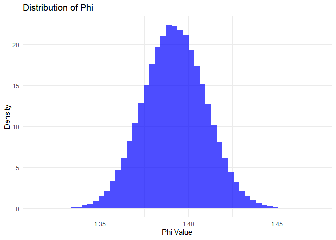

```r
# Plotting the distribution of Phi
ggplot(data.frame(phi_values), aes(x = phi_values)) + geom_histogram(aes(y = ..density..),
    bins = 50, fill = "blue", alpha = 0.7) + labs(title = "Distribution of Phi",
    x = "Phi Value", y = "Density") + theme_minimal()
```

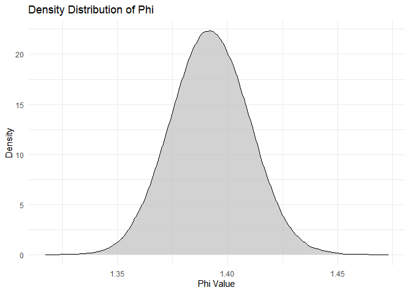

```r
ggplot(data.frame(phi_values), aes(x = phi_values)) + geom_density(fill = "gray",
    alpha = 0.7) + labs(title = "Density Distribution of Phi", x = "Phi Value", y = "Density") +
    theme_minimal()
```

# Performing swapping algorithm

Convert the multinomial distribution data into a 2 x n tabular format, then select a subset of the data and perform a swapping algorithm on it where the swapping rate is 0.5 which means 50% of the data will be swapped (But not 50% of the data will be Perturbed).

**It is worth noting that since we only have 2 columns of data here, we make the match variable empty, use the first column as the hold variable, the second column as the swap variable and use the derangement function to perform swapping. Such a setting satisfies differential privacy when certain assumptions are met.**

```r
# Convert the multinomial data to N*2 table format: data_margin
n <- nrow(data)
data_margin <- matrix(NA, nrow = n, ncol = 2)

for (i in 1:n) {
    if (data[i, 1] == 1) {
        data_margin[i, ] <- c(1, 1)
    } else if (data[i, 2] == 1) {
        data_margin[i, ] <- c(1, 0)
    } else if (data[i, 3] == 1) {
        data_margin[i, ] <- c(0, 1)
    } else if (data[i, 4] == 1) {
        data_margin[i, ] <- c(0, 0)
    }
}

colnames(data_margin) <- c("Q1", "Q2")


derangr <- function(x) {
    v = 1:length(x)
    while (TRUE) {
        xp <- sample(v)
        if (sum(xp == v) == 0)
            break
    }
    return(x[xp])
}



# Determine which rows to swap based on probability p
p <- 0.5
swap_indicator <- rbinom(nrow(data_margin), 1, p)
selected <- which(swap_indicator == 1)

swapped_values <- derangr(data_margin[selected, 2])
data_swapped <- data_margin
data_swapped[selected, 2] <- swapped_values




# recalculate marginal table
marginal_table_swapped <- matrix(NA, nrow = 2, ncol = 2)
marginal_table_swapped[1, 1] <- sum(data_swapped[, 1] == 1 & data_swapped[, 2] ==
    1)
marginal_table_swapped[1, 2] <- sum(data_swapped[, 1] == 1 & data_swapped[, 2] ==
    0)
marginal_table_swapped[2, 1] <- sum(data_swapped[, 1] == 0 & data_swapped[, 2] ==
    1)
marginal_table_swapped[2, 2] <- sum(data_swapped[, 1] == 0 & data_swapped[, 2] ==
    0)

print(marginal_table_swapped)
```

```
##       [,1]  [,2]
## [1,] 26058 23750
## [2,] 24326 25866
```

```r
# Estimating θ values
theta_hat_swapped <- c(marginal_table_swapped[1, 1], marginal_table_swapped[1, 2],
    marginal_table_swapped[2, 1], marginal_table_swapped[2, 2])/n

# Calculating ϕ
phi_swapped <- theta_hat_swapped[1] * theta_hat_swapped[4]/(theta_hat_swapped[2] *
    theta_hat_swapped[3])
print(paste("phi_swapped:", phi_swapped))
```

```
## [1] "phi_swapped: 1.16663778067219"
```

# Dirichlet posterior model with swapped data

Here we have the same setting before: Calculate the posterior parameters for Dirichlet distribution and Plot the distribution of swapped $φ$.

$$\pi (\theta) \sim Dir(1,1,1,1)$$
As before but with swapped setting:
$$p (\theta\mid \tilde y) \sim Dir(1+\tilde
y_1,1+\tilde y_2,1+\tilde y_3,1+\tilde y_4)$$

```r
# Calculate the posterior parameters for Dirichlet distribution
alpha_prior <- c(1, 1, 1, 1)
data_counts_swapped <- as.vector(t(marginal_table_swapped))
alpha_posterior_swapped <- alpha_prior + data_counts_swapped

num_samples <- 1e+05

# Drawing samples from the posterior Dirichlet distribution
theta_samples_swapped <- matrix(NA, nrow = num_samples, ncol = 4)
for (i in 1:num_samples) {
    theta_samples_swapped[i, ] <- rdirichlet(1, alpha_posterior_swapped)
}

# Calculating Phi for each sample
phi_values_swapped <- theta_samples_swapped[, 1] * theta_samples_swapped[, 4]/(theta_samples_swapped[,
    2] * theta_samples_swapped[, 3])
difference <- mean(phi_values_swapped) - phi_star
print(paste("phi from swapped table:", mean(phi_values_swapped)))
```

```
## [1] "phi from swapped table: 1.16670615947445"
```

```r
print(paste("Difference:", difference))
```

```
## [1] "Difference: -0.21136567417394"
```

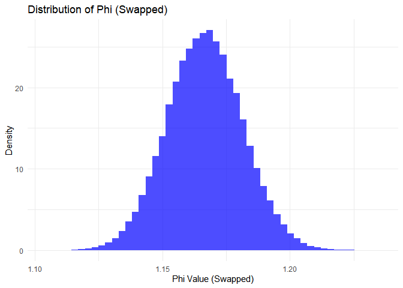

```r
# Plotting the distribution of Phi
ggplot(data.frame(phi_values_swapped), aes(x = phi_values_swapped)) + geom_histogram(aes(y = ..density..),
    bins = 50, fill = "blue", alpha = 0.7) + labs(title = "Distribution of Phi (Swapped)",
    x = "Phi Value (Swapped)", y = "Density") + theme_minimal()
```

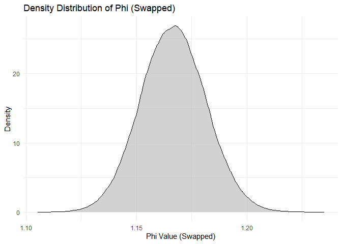

```r
ggplot(data.frame(phi_values_swapped), aes(x = phi_values_swapped)) + geom_density(fill = "gray",
    alpha = 0.7) + labs(title = "Density Distribution of Phi (Swapped)", x = "Phi Value (Swapped)",
    y = "Density") + theme_minimal()
```

# Plot the combined density plot

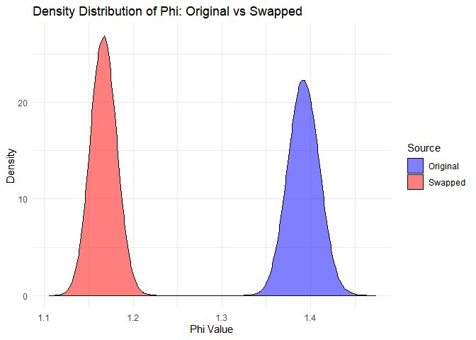

```r
# Combine the data into a single data frame for plotting
combined_data <- data.frame(Value = c(phi_values, phi_values_swapped), Source = factor(c(rep("Original",
    length(phi_values)), rep("Swapped", length(phi_values_swapped)))))

# Plot the combined density plot
ggplot(combined_data, aes(x = Value, fill = Source)) + geom_density(alpha = 0.5) +
    labs(title = "Density Distribution of Phi: Original vs Swapped", x = "Phi Value",
        y = "Density") + scale_fill_manual(values = c("blue", "red")) + theme_minimal()
```

# Empirical Observations

#### First, intuitively, we observe a decrease in the value of phi, confirming our initial query: it’s indeed feasible to alter the statistic’s value while preserving the marginal sum.

The same logic can may be applied in reverse, supported by numerical experiments, where an initial theta of (0.23, 0.27, 0.27, 0.23) results in a swapped $φ$ that’s always greater than the actual value.

**To prove our hypothesis, let’s run a simulation using the “symmetric” setting:**

$$\theta^* = (0.23, 0.27, 0.27,
0.23).$$
Data likelihood function and the definition of $φ$ are not changed. To simplify, we do not show the code and only show the comparison of density estimates obtained by sampling the posterior model using confidence data and swapped data (where the swapping rate is still 0.5).

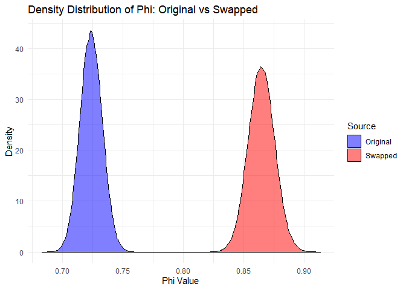

We have conducted many experiments, and we can confirm our hypothesis: the exchange algorithm will make $φ$, which is not 1, “drag” toward 1.

#### The swapping algorithm does change the value of the statistic and if we use private data to perform statistical inference directly, we will get a wrong conclusion - in our model, we will get a φ that is closer to 1 than the true value. And this also answers our second and third questions.

**In addition, we also discovered an interesting phenomenon:**

When
$$\theta^* = (0.23, 0.27,
0.27, 0.23).$$
The peak of the distribution of ϕ before swapping is higher than after swapping ϕ_tilde.

When
$$\theta^* = (0.27, 0.23,
0.23, 0.27).$$
The peak of the distribution of ϕ_tilde after swapping is higher than ϕ before swapping .

#### The swapping algorithm may affect the patterns and structures of the data in different ways under different settings. In some cases, swapping might increase the variability of certain statistics, while in others, it might reduce the variability of these statistics.

To confirm our idea, we conducted the following experiments:

**Apply swapping rate from 0.1,0.2,…,1 to the data with:**
$$\theta^* = (0.27, 0.23,
0.23, 0.27).$$

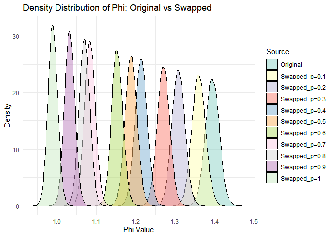

**Apply swapping rate from 0.1,0.2,…,1 to the data with:**
$$\theta^* = (0.23, 0.27,
0.27, 0.23).$$

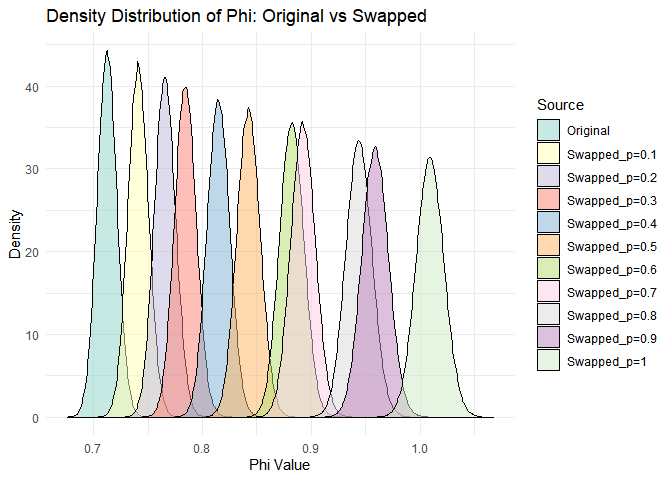

# Summary:

For
$$\theta^* = (0.23, 0.27, 0.27,
0.23).$$
The peak of the $φ$ distribution in the original data is around 0.7, indicating a relatively concentrated distribution.

#### As the swapping proportion p increases, the peak of the ϕ distribution gradually decreases, suggesting a decrease in data concentration. Concurrently, the value of ϕ is progressively pulled towards 1, indicating an increase in data uniformity, suggesting an increase in data uncertainty.

For
$$\theta^* = (0.27, 0.23, 0.23,
0.27).$$
The peak of the $φ$ distribution in the original data is around 1.4, indicating a relatively dispersed distribution.

#### As the swapping proportion p increases, the peak of the ϕ distribution gradually rises, suggesting an increase in data concentration. Concurrently, the value of ϕ is also progressively pulled towards 1, indicating an increase in data uniformity, *possibly* suggesting a decrease in data uncertainty, though this would require further statistical verification.

### Finally, let’s try a more extreme example

$$\theta^* = (0.7, 0.1, 0.1,
0.1)$$

### with different swapping rate.

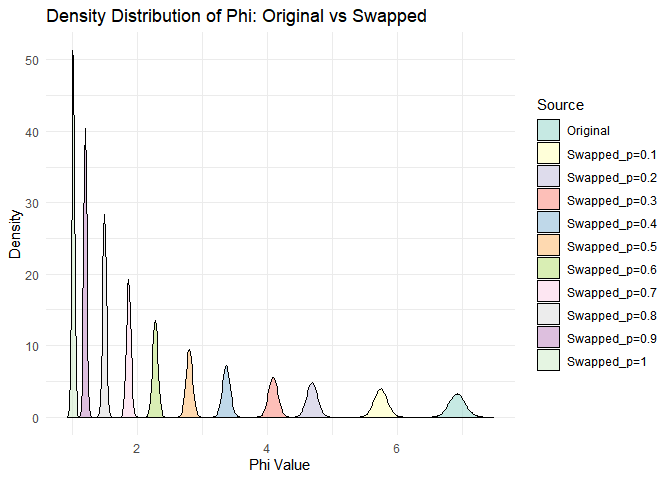

As expected, the exchange algorithm makes extreme $φ$ changes more elusive, and as described above, a phi far away from 1 will obtain a more dispersed distribution by sampling from the posterior distribution model. As the exchange rate increases, the peak of the $φ$ distribution gradually rises, and the shape of the probability density estimate becomes more concentrated and sharp.

### Therefore, we can draw the following conclusion from the above figures: As p increases, the number of rows selected for swapping also increases, so the internal structure (information) of the data itself is destroyed more. When p=1, the structure is completely destroyed. At this time, regardless of the initial setting of θ, the mean value of φ is near 1.

In order to ensure that when p = 1 we get $φ$ that deviates slightly from 1 because of Monte Carlo error rather than some structural information that is not destroyed by the swapping algorithm. We no longer set the seed and run the algorithm with an swapping rate of 1 multiple times, and finally plot the multiple exchanged data into a graph.

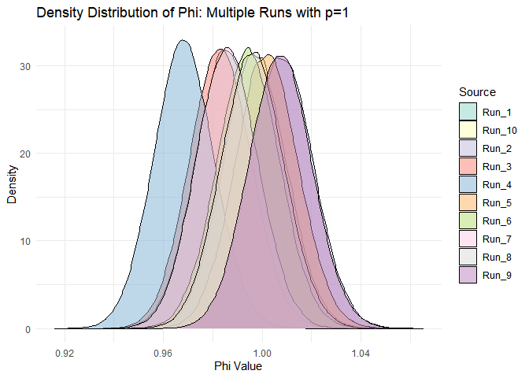

# Conclusions:

The impact of the swapping algorithm on the data is contingent upon the setting of θ∗. Different θ∗ settings lead to different trends in the ϕ distribution.

The swapping algorithm tends to pull the ϕ value towards 1, possibly due to the increase in data uniformity introduced by the swaps.

Implications for Data Privacy: From this perspective, if the goal is to enhance the anonymity or randomness of the data, this swapping method appears to be effective. The process introduces more randomness, potentially breaking some of the structures or patterns present in the original data.

Considerations for Data Structure: On the other hand, if the aim is to retain certain structures or patterns inherent in the original data, then we might need to think of some other methods. The swapping, as observed, might disrupt some of the original data characteristics.

# Let’s play around with 3 columns example

# Data Generation

Since now our number of theta has increased, we try to do a simple simulation first with:
$$\theta^* = (0.15,
0.1, 0.15, 0.1, 0.15, 0.1, 0.15, 0.1).$$

```
## Combinations of Q1, Q2 and Q3 with corresponding theta values:
```

| Q1 | Q2 | Q3 | Corresponding Theta Values |
| --- | --- | --- | --- |
| 0 | 0 | 0 | 0.15 |
| 1 | 0 | 0 | 0.1 |
| 0 | 1 | 0 | 0.15 |
| 1 | 1 | 0 | 0.1 |
| 0 | 0 | 1 | 0.15 |
| 1 | 0 | 1 | 0.1 |
| 0 | 1 | 1 | 0.15 |
| 1 | 1 | 1 | 0.1 |

```
## Combinations of Q2 and Q3 with corresponding theta values:
```

[output not shown]

```r
# Data Generation
n <- 1e+05
# Example probabilities for the 8 combinations
theta <- c(0.15, 0.1, 0.15, 0.1, 0.15, 0.1, 0.15, 0.1)

# Generate all possible combinations
combinations <- expand.grid(Q1 = c(0, 1), Q2 = c(0, 1), Q3 = c(0, 1))

# Randomly sample rows based on the probabilities in theta
sampled_rows <- sample(1:8, size = n, replace = TRUE, prob = theta)

# Create the data frame
data_3cols <- combinations[sampled_rows, ]
head(data_3cols)
```

```
##     Q1 Q2 Q3
## 6    1  0  1
## 5    0  0  1
## 5.1  0  0  1
## 2    1  0  0
## 6.1  1  0  1
## 3    0  1  0
```

```r
# Constructing the 2x2 Marginal Tables
marginal_table_Q1Q2 <- table(data_3cols$Q1, data_3cols$Q2)
marginal_table_Q1Q3 <- table(data_3cols$Q1, data_3cols$Q3)
marginal_table_Q2Q3 <- table(data_3cols$Q2, data_3cols$Q3)

phi_star <- (theta[1] + theta[5]) * (theta[4] + theta[8])/((theta[2] + theta[6]) *
    (theta[3] + theta[7]))
```

# Dirichlet posterior model with confidence data

```r
alpha_prior <- c(1, 1, 1, 1)
data_counts <- as.vector(t(marginal_table_Q2Q3))
alpha_posterior <- alpha_prior + data_counts

num_samples <- 1e+05

# Drawing samples from the posterior Dirichlet distribution
theta_samples <- matrix(NA, nrow = num_samples, ncol = 4)
for (i in 1:num_samples) {
    theta_samples[i, ] <- rdirichlet(1, alpha_posterior)
}

# Calculating Phi for each sample
phi_values <- theta_samples[, 1] * theta_samples[, 4]/(theta_samples[, 2] * theta_samples[,
    3])
difference <- mean(phi_values) - phi_star
print(paste("phi from actual posterior:", mean(phi_values)))
```

```
## [1] "phi from actual posterior: 1.00915674794015"
```

```r
print(paste("Difference:", difference))
```

```
## [1] "Difference: 0.0091567479401502"
```

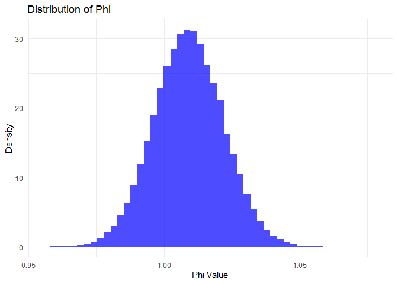

```r
# Plotting the distribution of Phi
ggplot(data.frame(phi_values), aes(x = phi_values)) + geom_histogram(aes(y = ..density..),
    bins = 50, fill = "blue", alpha = 0.7) + labs(title = "Distribution of Phi",
    x = "Phi Value", y = "Density") + theme_minimal()
```

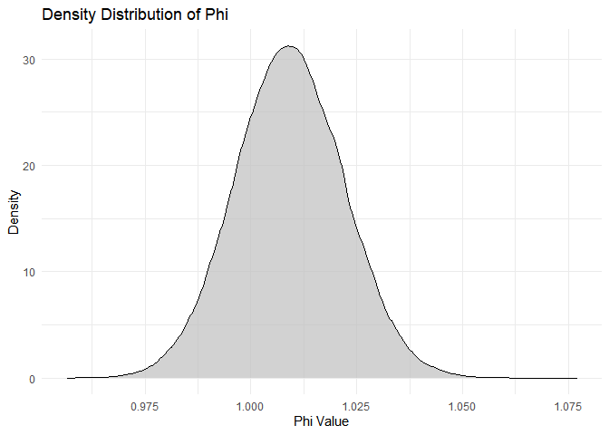

```r
ggplot(data.frame(phi_values), aes(x = phi_values)) + geom_density(fill = "gray",
    alpha = 0.7) + labs(title = "Density Distribution of Phi", x = "Phi Value", y = "Density") +
    theme_minimal()
```

It is worth noting that our settings are relatively uniform. Especially when we consider the marginal table composed of Q2 and Q3, we will find that the theoretical phi should be equal to 1 at this situation.

# Define and apply the DP Swapping function

Here we use swap.var = ‘Q3’, match.var =‘Q1’, hold.var = ‘Q2’ to perform the swapping where swapping rate is 0.05.

What we’re actually doing is swapping Q3 while keeping the marginal distribution of Q2 constant, and using Q1 as the matching variable to decide which rows should be swapped. This is very similar to the two column case, except now you have an extra column Q1 as the matching variable.

```r
# Apply DPSwap function
DPSwap <- function(data, swap.rate, nsim = 1, swap.var = "swap", match.var = "match",
    hold.var = "hold", use.derangement = T) {
    # dat must have three columns: swap, match, and hold their names can be
    # specified differently p is the swap rate nsim: number of copies needed if
    # use.derangement = F, simple permutation is used

    names <- c(swap = swap.var, match = match.var, hold = hold.var)
    dat <- rename(data, all_of(names)) %>%
        rowid_to_column(var = "index")
    levels <- distinct(dat, match) %>%
        pull
    dat_return <- dat %>%
        subset(NA) %>%
        add_column(iteration = NA, p = NA)

    for (p in swap.rate) {
        cat("swap rate =", p, "\n")
        dat_ <- dat_return %>%
            subset(NA)
        ct_ <- 0

        for (j in levels) {
            ct_ <- ct_ + 1
            cat(ct_, "of", length(levels), "levels,", match.var, "=", j, "\n")
            chunk_ <- dat %>%
                filter(match == j)
            index_current <- chunk_$index
            n_chunk_ <- length(index_current)

            if (n_chunk_ > 1) {
                for (k in 1:nsim) {
                  i_ <- rbinom(n_chunk_, size = 1, prob = p)
                  while (sum(i_) == 1) {
                    i_ <- rbinom(n_chunk_, size = 1, prob = p)
                  }
                  swap_locations <- which(i_ == 1)
                  i_swap <- index_current[swap_locations]
                  if (use.derangement == T) {
                    i_swapped <- derangr(i_swap)
                  } else {
                    i_swapped <- sample(i_swap, replace = F)
                  }
                  index_new <- index_current
                  index_new[swap_locations] <- i_swapped
                  chunk_new <- chunk_
                  chunk_new$swap <- chunk_$swap[match(chunk_$index, index_new)]
                  chunk_new$iteration <- k
                  dat_ <- dat_ %>%
                    bind_rows(chunk_new)
                }
            } else {
                chunk_new <- chunk_
                for (k in 1:nsim) {
                  chunk_new$iteration <- k
                  dat_ <- dat_ %>%
                    bind_rows(chunk_new)
                }
            }
        }
        dat_$p <- p
        dat_return <- dat_return %>%
            bind_rows(dat_)
    }
    return(dat_return)
}

swap.rate <- 0.05
data_swapped <- DPSwap(data_3cols, swap.rate, nsim = 1, swap.var = "Q3", match.var = "Q1",
    hold.var = "Q2")
```

```
## swap rate = 0.05
## 1 of 2 levels, Q1 = 1
## 2 of 2 levels, Q1 = 0
```